# IODS course project

Scarabel

# About the project

*This is the project for the course Introduction to Open Data Science, fall 2017.*

My name is Francesca Scarabel, this is the first week exercise of the course Open Data Science. My github repository is available at this [link](https://github.com/scarabel/IODS-project)

# Chapter 2: regression and model validation

*Goal of this project is to practice regression and model validation with R on a dataset which is saved in the directory IODS-project under the name “learning2014”. The dataset is obtained from the first part of the RStudio Exercise 2, with the code available at [my Github repository](https://github.com/scarabel/IODS-project/blob/master/data/create_learning2014.R).*

What I learnt:

- to produce summaries and graphical representations of the data
- to fit a linear regression model to the data
- to validate the model with graphical tools

## The database

I first load the dataset from the folder IODS-project and save it with name “students2014”.

```r
setwd("~/GitHub/IODS-project")
options(max.print=2000)
students2014 <- read.csv("learning2014")
```

The structure of the database can be explored with the instruction `str`:

```r
str(students2014)
```

```
## 'data.frame':    166 obs. of  8 variables:
##  $ X       : int  1 2 3 4 5 6 7 8 9 10 ...
##  $ gender  : Factor w/ 2 levels "F","M": 1 2 1 2 2 1 2 1 2 1 ...
##  $ age     : int  53 55 49 53 49 38 50 37 37 42 ...
##  $ attitude: int  37 31 25 35 37 38 35 29 38 21 ...
##  $ deep    : num  3.58 2.92 3.5 3.5 3.67 ...
##  $ stra    : num  3.38 2.75 3.62 3.12 3.62 ...
##  $ surf    : num  2.58 3.17 2.25 2.25 2.83 ...
##  $ points  : int  25 12 24 10 22 21 21 31 24 26 ...
```

The database contains a summary of the information about statistical learning collected by Kimmo Venhalahti during the period 3.12.2014 - 10.1.2015, from the students attnding the course *Johdatus yhteiskuntatilastotieteeseen*. The full information was collected and summarised in the following fields:

- age = age in years;
- gender = gender of the students (M or F);
- attitude = attitude towards statistics;
- deep = summary of the variables characterising deep learning;
- stra = summary of the variables characterising strategic learning;
- surf = summary of the variables characterising surface learining;
- points = exam grade.

The database has 166 entries containing the data for every students who got a positive final grade.

## Graphical overview and summary of the data

I first give an overview of the age and gender of the interviewed students.

```r
summary(students2014$age)
```

```
##    Min. 1st Qu.  Median    Mean 3rd Qu.    Max.
##   17.00   21.00   22.00   25.51   27.00   55.00
```

```r
summary(students2014$gender)
```

```
##   F   M
## 110  56
```

To explore the relations between the variables, I create a scattered plot of the different variables, keeping track of the gender. To plot the results, I first load the library `ggplot2` and `GGally`

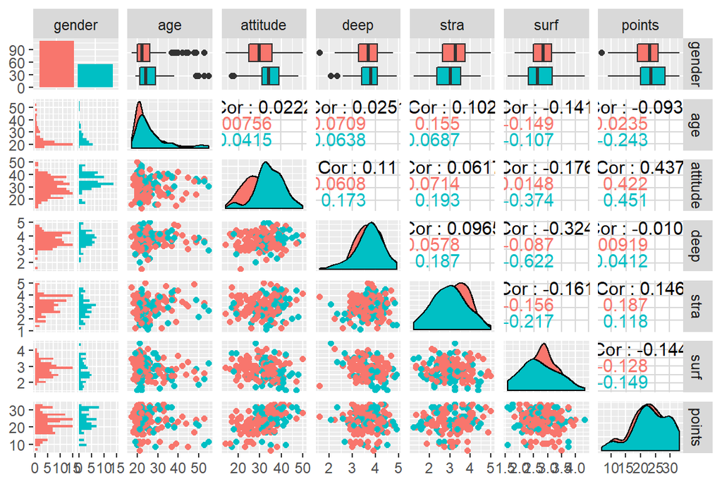

Some remarks about the results

I will explore graphically specifically the correlation between points and attitude, strategic learning and surface learning. In particular, below I repeat the graphic relation between the variables, including their linear regression line fitted to the data.

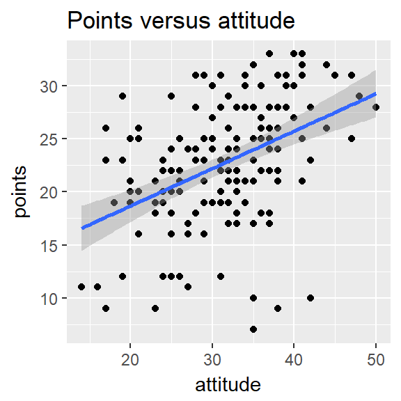

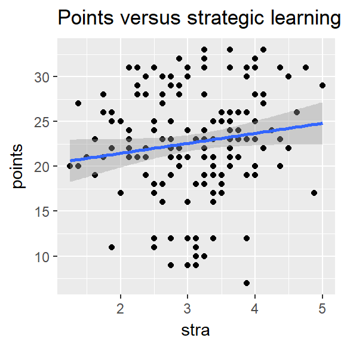

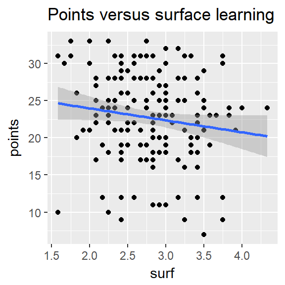

## Fitting a statistical linear regression model

I now fit a regression model for the target variable *point*, with explanatory variables $x_1=$ *attitude*, $x_2=$ *strategic learning* and $x_3=$ *surface learning*.

```r
my_model <- lm(points ~ attitude + stra + surf, data = students2014)
summary(my_model)
```

```
##
## Call:
## lm(formula = points ~ attitude + stra + surf, data = students2014)
##
## Residuals:
##      Min       1Q   Median       3Q      Max
## -17.1550  -3.4346   0.5156   3.6401  10.8952
##
## Coefficients:
##             Estimate Std. Error t value Pr(>|t|)
## (Intercept) 11.01711    3.68375   2.991  0.00322 **
## attitude     0.33952    0.05741   5.913 1.93e-08 ***
## stra         0.85313    0.54159   1.575  0.11716
## surf        -0.58607    0.80138  -0.731  0.46563
## ---
## Signif. codes:  0 '***' 0.001 '**' 0.01 '*' 0.05 '.' 0.1 ' ' 1
##
## Residual standard error: 5.296 on 162 degrees of freedom
## Multiple R-squared:  0.2074, Adjusted R-squared:  0.1927
## F-statistic: 14.13 on 3 and 162 DF,  p-value: 3.156e-08
```

The summary of the statistical model provides the coefficients of the multiple linear regression model for the explanatory variables $x_1,x_2,x_3$. The coefficients are $\beta_1 \approx 0.33, \beta_2 \approx 0.85, \beta_3 \approx -0.58$.

To understand the significance of the model, we look at the p-value, `Pr(>|t|)`. We observe that the p-value corresponding to the surface learning is very high, so this variable is probably not relevant in explaining the exam points.

We therefore take it out the model and consider only the first two explanatory variables.

```r
my_model2 <- lm(points ~ attitude + stra, data = students2014)
summary(my_model2)
```

```
##
## Call:
## lm(formula = points ~ attitude + stra, data = students2014)
##
## Residuals:
##      Min       1Q   Median       3Q      Max
## -17.6436  -3.3113   0.5575   3.7928  10.9295
##
## Coefficients:
##             Estimate Std. Error t value Pr(>|t|)
## (Intercept)  8.97290    2.39591   3.745  0.00025 ***
## attitude     0.34658    0.05652   6.132 6.31e-09 ***
## stra         0.91365    0.53447   1.709  0.08927 .
## ---
## Signif. codes:  0 '***' 0.001 '**' 0.01 '*' 0.05 '.' 0.1 ' ' 1
##
## Residual standard error: 5.289 on 163 degrees of freedom
## Multiple R-squared:  0.2048, Adjusted R-squared:  0.1951
## F-statistic: 20.99 on 2 and 163 DF,  p-value: 7.734e-09
```

## Interpretation of the regression coefficients

In this new model, the coefficients of the explanatory variables are $\beta_1\approx 0.34$ and $\beta_2\approx 0.91$. This means that for any unitary increase of attitude or strategic learning, the points are expected to increase of 0.34 or 0.91, respectively. Hence, the strategic learning seems to have a higher effect on the exam points.

The value of $R^2$ indicates how well the data are explained by the linear regression model. A value of 0.2 indicates that the data are quite scattered away from the regression line (i.e., the dispersion of the data is quite high). Compare also the previous plots of points vs attitude and points vs strategic learning.

## Graphical model validation

To understand how reasonable is the assumption $\epsilon \sim N(0,\sigma^2)$, I plot the diagnostic plots: Residuals vs Fitted values, Normal QQ-plot and Residuals vs Leverage.

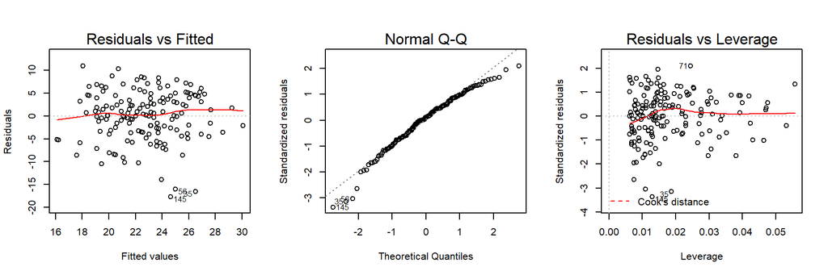

- From the first plot, there seems to be no pattern between data and residuals. Hence it is reasonable to assume that the noise $\epsilon$ is independent of the data (i.e., the variance $\sigma^2$ is constant).
- The second plot shows that the stardardised residuals fit well with the straight line: the normality assumption is reasonable.
- The third plot shows that there are no important outliers in the data that have high impact in the fitting of the model. Notice the small values of the leverage in the $x$-axis.

# Chapter 3: Logistic regression

*Goal of this project is to explore a data set and perform and interpret the logistic regression analysis. The dataset ‘alc’ is obtained by the previous data wrangling exercise 3.*

What I learnt:

- to fit a regression model to categorical data
- to make predictions from the model
- to perform a K-fold cross validation of the model by studying the number of wrong preditions

## The database

The database I am going to study is obtained to approach students’ achievement in secondary education of two Portuguese schools. The data attributes include student grades, demographic, social and school related features) and it was collected by using school reports and questionnaires. Two datasets are provided regarding the performance in two distinct subjects: Mathematics (mat) and Portuguese language (por). The original database is available [here](https://archive.ics.uci.edu/ml/datasets/Student+Performance). In the data wrangling exercise, we joined the data sets into the new dataset ‘alc’ by combining the two student alcohol consumption data sets. The following adjustments have been made: the variables not used for joining the two data have been combined by averaging (including the grade variables); ‘alc_use’ is the average of ‘Dalc’ and ‘Walc’; ‘high_use’ is TRUE if ‘alc_use’ is higher than 2 and FALSE otherwise The final database ‘alc’ hase 382 entrie and 36 fields.

I load the dataset ‘alc’ from the subfolder ‘data’ in the folder ‘IODS-project’, and I print out the fields’ names.

```r
setwd("~/GitHub/IODS-project/data")
alc <- read.csv("alc")
colnames(alc)
```

```
##  [1] "X"          "school"     "sex"        "age"        "address"
##  [6] "famsize"    "Pstatus"    "Medu"       "Fedu"       "Mjob"
## [11] "Fjob"       "reason"     "nursery"    "internet"   "guardian"
## [16] "traveltime" "studytime"  "failures"   "schoolsup"  "famsup"
## [21] "paid"       "activities" "higher"     "romantic"   "famrel"
## [26] "freetime"   "goout"      "Dalc"       "Walc"       "health"
## [31] "absences"   "G1"         "G2"         "G3"         "alc_use"
## [36] "high_use"
```

```r
dim(alc)
```

```
## [1] 382  36
```

I will investigate the relation betweek high alcohol consumption and the following variables:

- famrel - quality of family relationships (numeric: from 1 - very bad to 5 - excellent)
- Medu, Fedu - mother/father’s education (numeric: 0 - none, 1 - primary education (4th grade), 2 - 5th to 9th grade, 3 - secondary education, or 4 - higher education). I define a variable Pedu (“parents’ education”) containing the avarage of Medu and Fedu
- goout - going out with friends (numeric: from 1 - very low to 5 - very high)
- absences - number of school absences (numeric: from 0 to 93)

My hypothesis is that alcohol consumption may be positively correlated with low quality of family relationships orlow education level of the parents. I will also investigate if a alcohol consumption is a group phenomenon (students that often go out with friends), or is correlated with loneliness (students that do not go out often). Finally, I will investigate the correlation between alcohol consumption and absences from school.

## Overview of the variables of interest

I present here a brief overview of the variables selected for the analysis

```r
summary(alc$activities)
```

```
##  no yes
## 181 201
```

```r
summary(alc$famrel)
```

```
##    Min. 1st Qu.  Median    Mean 3rd Qu.    Max.
##   1.000   4.000   4.000   3.937   5.000   5.000
```

```r
summary(alc$Pedu)
```

```
##    Min. 1st Qu.  Median    Mean 3rd Qu.    Max.
##   0.500   2.000   3.000   2.686   3.500   4.000
```

```r
summary(alc$goout)
```

```
##    Min. 1st Qu.  Median    Mean 3rd Qu.    Max.
##   1.000   2.000   3.000   3.113   4.000   5.000
```

```r
summary(alc$absences)
```

```
##    Min. 1st Qu.  Median    Mean 3rd Qu.    Max.
##     0.0     1.0     3.0     4.5     6.0    45.0
```

Graphically, I explore how the selected variables are correlated with high alcohol consumption:

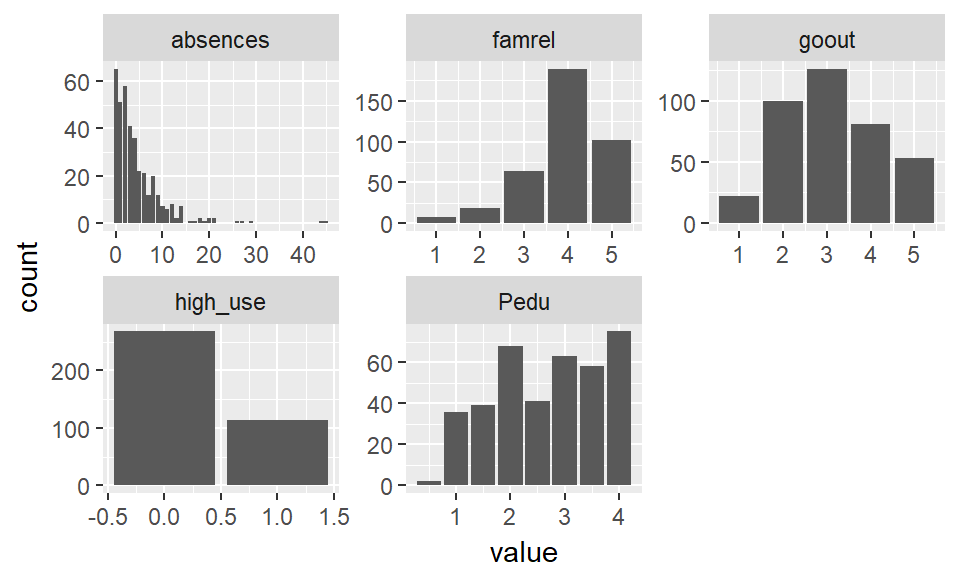

To explore the relations between the variables, I create a scattered plot of the different variables.

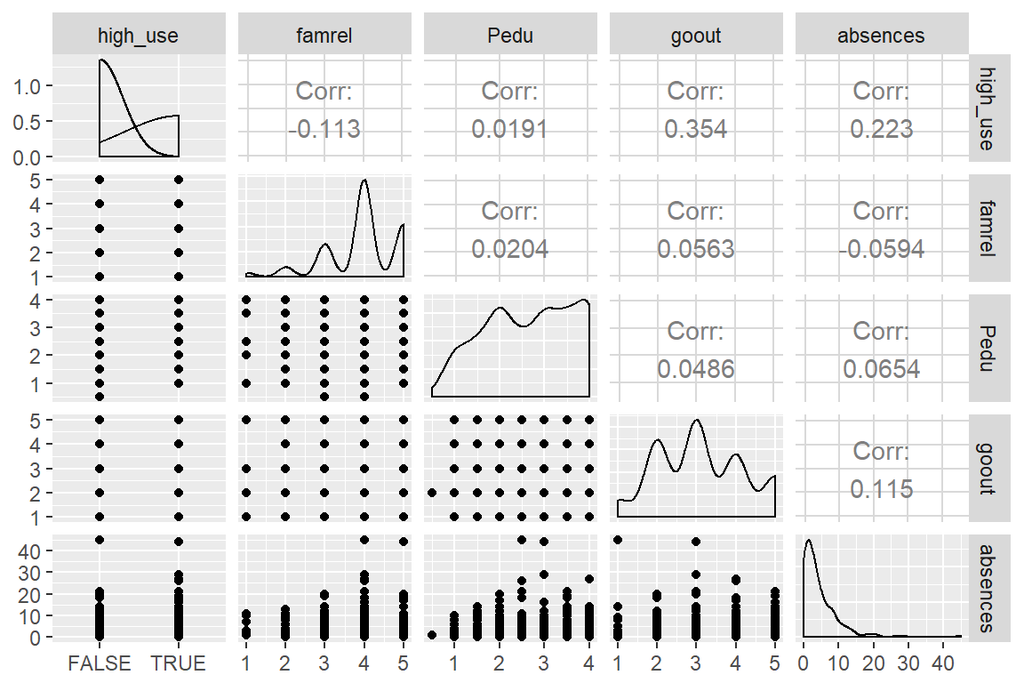

From the plot, we can draw some first observations about the correlation between the variables:

- worse family relations are correlated with higher alcohol consumption
- going out with friends often is correlated with higher alcohol consumption.
- higher alcohol consumption is correlated with higher number of absences from school
- no significant correlation emerges with parents’ education.

## Logistic regression

I define a regression model for the four exaplanatory variables. I print the summary of the regression model and the coefficients.

```
##
## Call:
## glm(formula = high_use ~ famrel + Pedu + goout + absences, family = "binomial",
##     data = alc_red)
##
## Deviance Residuals:
##     Min       1Q   Median       3Q      Max
## -1.9074  -0.7629  -0.5478   0.9010   2.4175
##
## Coefficients:
##             Estimate Std. Error z value Pr(>|z|)
## (Intercept) -2.31150    0.70876  -3.261 0.001109 **
## famrel      -0.35076    0.13541  -2.590 0.009588 **
## Pedu        -0.02954    0.12499  -0.236 0.813141
## goout        0.77202    0.11995   6.436 1.23e-10 ***
## absences     0.07478    0.02178   3.433 0.000598 ***
## ---
## Signif. codes:  0 '***' 0.001 '**' 0.01 '*' 0.05 '.' 0.1 ' ' 1
##
## (Dispersion parameter for binomial family taken to be 1)
##
##     Null deviance: 465.68  on 381  degrees of freedom
## Residual deviance: 395.73  on 377  degrees of freedom
## AIC: 405.73
##
## Number of Fisher Scoring iterations: 4
```

```
## (Intercept)      famrel        Pedu       goout    absences
## -2.31149751 -0.35076352 -0.02954349  0.77202012  0.07477908
```

The exponential function of the coefficients of the model gives us the odds ratios of the variables. Therefore, I can obtain the odds ratios and their confidence intervals by taking the exponential function:

```r
OR <- coef(m) %>% exp
CI <- confint(m) %>% exp
cbind(OR, CI)
```

```
##                     OR      2.5 %    97.5 %
## (Intercept) 0.09911272 0.02377955 0.3859057
## famrel      0.70415025 0.53853099 0.9174582
## Pedu        0.97088865 0.75975770 1.2414755
## goout       2.16413365 1.72107900 2.7573129
## absences    1.07764605 1.03377054 1.1273516
```

From the summary of our model, by looking at the p-value we notice that only ‘famrel’, ‘goout’ and ‘absences’ are significant to explain ‘high_use’ (p-value less than 0.05), while ‘Pedu’ is not significant. This is clear also from the odds ratios and their confidence intervals: the confidence intervals for the variable ‘Pedu’ contains the value 1 for the odd ratio, meaning that, given the value of ‘Pedu’, we predict high or low alcohol consumption with the same probability. In practice, ‘Pedu’ does not help in predicting the alcohol consumption of an individual.

Hence, we define another model by keeping only the significant three variables.

```r
m2 <- glm(high_use ~ famrel + goout + absences, data = alc_red, family = "binomial")
summary(m2)
```

```
##
## Call:
## glm(formula = high_use ~ famrel + goout + absences, family = "binomial",
##     data = alc_red)
##
## Deviance Residuals:
##     Min       1Q   Median       3Q      Max
## -1.9018  -0.7731  -0.5466   0.9002   2.4180
##
## Coefficients:
##             Estimate Std. Error z value Pr(>|z|)
## (Intercept) -2.38825    0.63161  -3.781 0.000156 ***
## famrel      -0.34986    0.13534  -2.585 0.009735 **
## goout        0.77071    0.11981   6.433 1.25e-10 ***
## absences     0.07446    0.02174   3.425 0.000615 ***
## ---
## Signif. codes:  0 '***' 0.001 '**' 0.01 '*' 0.05 '.' 0.1 ' ' 1
##
## (Dispersion parameter for binomial family taken to be 1)
##
##     Null deviance: 465.68  on 381  degrees of freedom
## Residual deviance: 395.79  on 378  degrees of freedom
## AIC: 403.79
##
## Number of Fisher Scoring iterations: 4
```

```r
OR <- coef(m2) %>% exp
CI <- confint(m2) %>% exp
cbind(OR, CI)
```

```
##                    OR      2.5 %    97.5 %
## (Intercept) 0.0917904 0.02572428 0.3085338
## famrel      0.7047893 0.53909482 0.9181526
## goout       2.1613089 1.71931650 2.7529251
## absences    1.0772983 1.03352289 1.1268709
```

## Predictive power of the model

I now use the model ‘m2’ to make predictions about alcohol consumption. I define a new field in the dataset ‘alc_red’ with a logical value if the predicted probability of high consumption is higher than 0.5.

```r
predictions <- predict(m2, type = "response")
alc_red <- mutate(alc_red, predictions = predictions>0.5)
table(high_use=alc_red$high_use,prediction=alc_red$predictions)
```

```
##         prediction
## high_use FALSE TRUE
##    FALSE   244   24
##    TRUE     69   45
```

I count the proportion of wrong predictions (inaccurately classified individuals) from the dataset:

```r
wrong <- abs(alc_red$high_use-alc_red$predictions)>0.5
mean(wrong)
```

```
## [1] 0.2434555
```

Slightly less than 1 over 4 predictions is wrong. Random guessing would give a proportion of wrong predictions of about 0.5. This means that the model ‘m2’ predicts the correct status if the individual (high/low alcohol consumption) in 3 cases out of 4. I think the predictive power is quite good.

## Cross validation

To understand more deeply the predictive power of the model, I perform the cross validation. In particular, in the 10-fold cross validation, the dataset is divided into 10 subsets, and each time nine subsets are used for training, (i.e., estimating the coefficients of the regression model), and the last one is used for assessing the predictive power of the model.

```r
library(boot)
loss_func <- function(class, prob) {
  n_wrong <- abs(class - prob) > 0.5
  mean(n_wrong)
}
cv <- cv.glm(data=alc_red, cost=loss_func, glmfit=m2, K=10)
cv$delta[1]
```

```
## [1] 0.2460733
```

I notice that model ‘m2’ has better performance (i.e., smaller prediction error using 10-fold cross-validation) than the DataCamp model, which has about 0.26 error. The new model suggests that alcohol consumption should be studied as group phenomenon, because of the high correlation with the habit of going out with group of friends.

# Chapter 4: Clustering and classification

*Goal of this project is to explore Boston dataset about Housing values in suburbs of Boston.*

What I learnt:

- to divide a dataset into train and test subsets
- to convert a continuous variable into a categorical variable
- to use linear discriminant analysis (LDA) for expressing one dependent variable as a linear combination of some explanatory variables
- k-means method to identify clusters in the data
- to measure the distance between clusters and identify the optimal number of clusters

## The dataset

The database we analyse this week is the ‘Boston’ database, one of the databases available in R, in the ‘MASS’ library. The database has the following structure:

```
## 'data.frame':    506 obs. of  14 variables:
##  $ crim   : num  0.00632 0.02731 0.02729 0.03237 0.06905 ...
##  $ zn     : num  18 0 0 0 0 0 12.5 12.5 12.5 12.5 ...
##  $ indus  : num  2.31 7.07 7.07 2.18 2.18 2.18 7.87 7.87 7.87 7.87 ...
##  $ chas   : int  0 0 0 0 0 0 0 0 0 0 ...
##  $ nox    : num  0.538 0.469 0.469 0.458 0.458 0.458 0.524 0.524 0.524 0.524 ...
##  $ rm     : num  6.58 6.42 7.18 7 7.15 ...
##  $ age    : num  65.2 78.9 61.1 45.8 54.2 58.7 66.6 96.1 100 85.9 ...
##  $ dis    : num  4.09 4.97 4.97 6.06 6.06 ...
##  $ rad    : int  1 2 2 3 3 3 5 5 5 5 ...
##  $ tax    : num  296 242 242 222 222 222 311 311 311 311 ...
##  $ ptratio: num  15.3 17.8 17.8 18.7 18.7 18.7 15.2 15.2 15.2 15.2 ...
##  $ black  : num  397 397 393 395 397 ...
##  $ lstat  : num  4.98 9.14 4.03 2.94 5.33 ...
##  $ medv   : num  24 21.6 34.7 33.4 36.2 28.7 22.9 27.1 16.5 18.9 ...
```

The dataset has 14 different fields and 506 observations, regarding housing values in the suburbs of Boston. Further information available [here](https://stat.ethz.ch/R-manual/R-devel/library/MASS/html/Boston.html). Here are the summaries of the variables:

```
##       crim                zn             indus            chas
##  Min.   : 0.00632   Min.   :  0.00   Min.   : 0.46   Min.   :0.00000
##  1st Qu.: 0.08204   1st Qu.:  0.00   1st Qu.: 5.19   1st Qu.:0.00000
##  Median : 0.25651   Median :  0.00   Median : 9.69   Median :0.00000
##  Mean   : 3.61352   Mean   : 11.36   Mean   :11.14   Mean   :0.06917
##  3rd Qu.: 3.67708   3rd Qu.: 12.50   3rd Qu.:18.10   3rd Qu.:0.00000
##  Max.   :88.97620   Max.   :100.00   Max.   :27.74   Max.   :1.00000
##       nox               rm             age              dis
##  Min.   :0.3850   Min.   :3.561   Min.   :  2.90   Min.   : 1.130
##  1st Qu.:0.4490   1st Qu.:5.886   1st Qu.: 45.02   1st Qu.: 2.100
##  Median :0.5380   Median :6.208   Median : 77.50   Median : 3.207
##  Mean   :0.5547   Mean   :6.285   Mean   : 68.57   Mean   : 3.795
##  3rd Qu.:0.6240   3rd Qu.:6.623   3rd Qu.: 94.08   3rd Qu.: 5.188
##  Max.   :0.8710   Max.   :8.780   Max.   :100.00   Max.   :12.127
##       rad              tax           ptratio          black
##  Min.   : 1.000   Min.   :187.0   Min.   :12.60   Min.   :  0.32
##  1st Qu.: 4.000   1st Qu.:279.0   1st Qu.:17.40   1st Qu.:375.38
##  Median : 5.000   Median :330.0   Median :19.05   Median :391.44
##  Mean   : 9.549   Mean   :408.2   Mean   :18.46   Mean   :356.67
##  3rd Qu.:24.000   3rd Qu.:666.0   3rd Qu.:20.20   3rd Qu.:396.23
##  Max.   :24.000   Max.   :711.0   Max.   :22.00   Max.   :396.90
##      lstat            medv
##  Min.   : 1.73   Min.   : 5.00
##  1st Qu.: 6.95   1st Qu.:17.02
##  Median :11.36   Median :21.20
##  Mean   :12.65   Mean   :22.53
##  3rd Qu.:16.95   3rd Qu.:25.00
##  Max.   :37.97   Max.   :50.00
```

To understand the correlation between variables, a graphical representation of the value of correlation is useful:

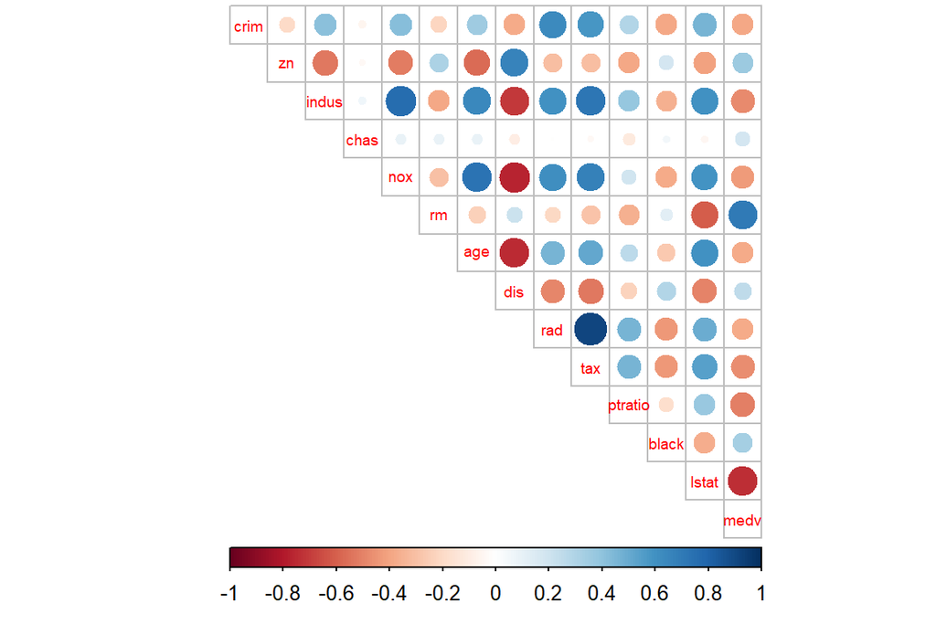

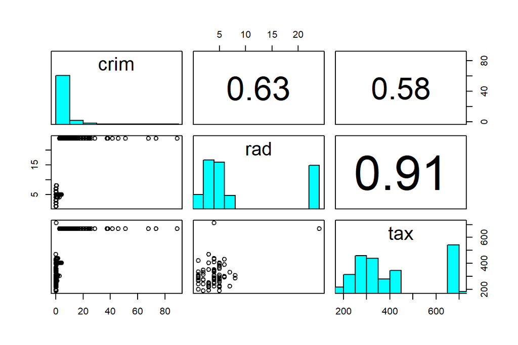

Notice the special distribution of ‘tax’ and ‘rad’, which are not Gaussian distributed, but present a number of observation which is isolated far to the right of the distribution. Notice once again the high correlation of ‘tax’ and ‘rad’ with ‘crim’.

## Standardization and train/test division

For the following analysis, I standardize the variables in the dataset. The function ‘scale’ does this action From the summary of the standardized data, observe that all variables have now mean zero.

```
##       crim                 zn               indus
##  Min.   :-0.419367   Min.   :-0.48724   Min.   :-1.5563
##  1st Qu.:-0.410563   1st Qu.:-0.48724   1st Qu.:-0.8668
##  Median :-0.390280   Median :-0.48724   Median :-0.2109
##  Mean   : 0.000000   Mean   : 0.00000   Mean   : 0.0000
##  3rd Qu.: 0.007389   3rd Qu.: 0.04872   3rd Qu.: 1.0150
##  Max.   : 9.924110   Max.   : 3.80047   Max.   : 2.4202
##       chas              nox                rm               age
##  Min.   :-0.2723   Min.   :-1.4644   Min.   :-3.8764   Min.   :-2.3331
##  1st Qu.:-0.2723   1st Qu.:-0.9121   1st Qu.:-0.5681   1st Qu.:-0.8366
##  Median :-0.2723   Median :-0.1441   Median :-0.1084   Median : 0.3171
##  Mean   : 0.0000   Mean   : 0.0000   Mean   : 0.0000   Mean   : 0.0000
##  3rd Qu.:-0.2723   3rd Qu.: 0.5981   3rd Qu.: 0.4823   3rd Qu.: 0.9059
##  Max.   : 3.6648   Max.   : 2.7296   Max.   : 3.5515   Max.   : 1.1164
##       dis               rad               tax             ptratio
##  Min.   :-1.2658   Min.   :-0.9819   Min.   :-1.3127   Min.   :-2.7047
##  1st Qu.:-0.8049   1st Qu.:-0.6373   1st Qu.:-0.7668   1st Qu.:-0.4876
##  Median :-0.2790   Median :-0.5225   Median :-0.4642   Median : 0.2746
##  Mean   : 0.0000   Mean   : 0.0000   Mean   : 0.0000   Mean   : 0.0000
##  3rd Qu.: 0.6617   3rd Qu.: 1.6596   3rd Qu.: 1.5294   3rd Qu.: 0.8058
##  Max.   : 3.9566   Max.   : 1.6596   Max.   : 1.7964   Max.   : 1.6372
##      black             lstat              medv
##  Min.   :-3.9033   Min.   :-1.5296   Min.   :-1.9063
##  1st Qu.: 0.2049   1st Qu.:-0.7986   1st Qu.:-0.5989
##  Median : 0.3808   Median :-0.1811   Median :-0.1449
##  Mean   : 0.0000   Mean   : 0.0000   Mean   : 0.0000
##  3rd Qu.: 0.4332   3rd Qu.: 0.6024   3rd Qu.: 0.2683
##  Max.   : 0.4406   Max.   : 3.5453   Max.   : 2.9865
```

Then, I transform the continuous variable ‘crim’ into a categorical variable by using its quatiles, and I add a new categorical variable ‘crime’ to the ‘boston_scaled’ dataset.

```r
summary(boston_scaled$crime)
```

```
##      low  med_low med_high     high
##      127      126      126      127
```

I now divide the dataset ‘boston_scaled’ into a train set containing a 80% of the original rows (404 randomly chosen rows) and a test set, containing the remaining 20% of the rows (i.e., 102 rows).

```r
str(train)
```

```
## 'data.frame':    404 obs. of  14 variables:
##  $ zn     : num  -0.487 -0.487 -0.487 -0.487 0.456 ...
##  $ indus  : num  -0.7196 -0.0797 1.015 -0.3756 -0.7692 ...
##  $ chas   : num  -0.272 -0.272 -0.272 -0.272 -0.272 ...
##  $ nox    : num  -0.412 -0.567 0.218 -0.299 -1.067 ...
##  $ rm     : num  -0.283 -0.146 -0.167 0.63 0.288 ...
##  $ age    : num  -0.251 -0.93 0.548 0.402 -1.974 ...
##  $ dis    : num  -0.068 0.0714 -0.3617 -0.4831 1.7104 ...
##  $ rad    : num  -0.178 -0.637 1.66 -0.522 -0.293 ...
##  $ tax    : num  -0.601 -0.779 1.529 -0.144 -0.464 ...
##  $ ptratio: num  -0.4876 0.0667 0.8058 1.1291 0.2977 ...
##  $ black  : num  0.22 0.405 0.441 0.417 0.434 ...
##  $ lstat  : num  -0.248 -0.446 0.509 -0.453 -0.946 ...
##  $ medv   : num  0.16 0.268 -0.286 0.54 0.203 ...
##  $ crime  : Factor w/ 4 levels "low","med_low",..: 3 2 4 2 2 4 3 1 1 1 ...
```

```r
str(test)
```

```
## 'data.frame':    102 obs. of  14 variables:
##  $ zn     : num  0.2845 -0.4872 0.0487 0.0487 -0.4872 ...
##  $ indus  : num  -1.287 -0.593 -0.476 -0.476 -0.437 ...
##  $ chas   : num  -0.272 -0.272 -0.272 -0.272 -0.272 ...
##  $ nox    : num  -0.144 -0.74 -0.265 -0.265 -0.144 ...
##  $ rm     : num  0.413 1.281 -0.399 -0.563 -0.498 ...
##  $ age    : num  -0.12 -0.266 0.615 -1.051 -1.395 ...
##  $ dis    : num  0.14 0.557 1.328 0.786 0.334 ...
##  $ rad    : num  -0.982 -0.867 -0.522 -0.522 -0.637 ...
##  $ tax    : num  -0.666 -0.986 -0.577 -0.577 -0.601 ...
##  $ ptratio: num  -1.458 -0.303 -1.504 -1.504 1.175 ...
##  $ black  : num  0.441 0.396 0.329 0.371 0.331 ...
##  $ lstat  : num  -1.074 -1.208 0.623 0.428 -0.85 ...
##  $ medv   : num  0.1595 1.3229 -0.395 -0.0906 0.0617 ...
##  $ crime  : Factor w/ 4 levels "low","med_low",..: 1 1 2 2 3 3 3 1 2 2 ...
```

## Linear Discriminant Analysis

Fit the linear discriminant analysis on the train set. Use the categorical crime rate as the target variable and all the other variables in the dataset as predictor variables. Draw the LDA (bi)plot.

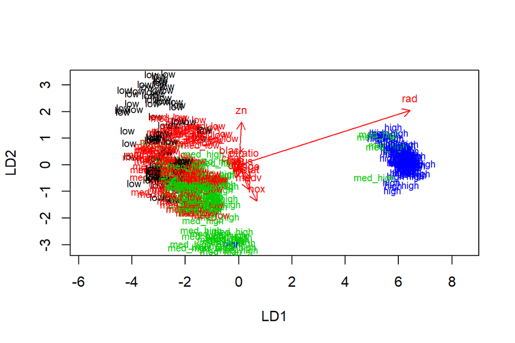

From the size of the arrows, we understand that ‘rad’, ‘nox’ (nitrogen oxides concentration, parts per 10 million) and ‘zn’ (proportion of residential land zoned for lots over 25,000 sq.ft) have the highest correlation on ‘crime’.

## Prediction on the test subset

Save the crime categories from the test set and then remove the categorical crime variable from the test dataset. Then predict the classes with the LDA model on the test data. Cross tabulate the results with the crime categories from the test set.

```
##           predicted
## correct    low med_low med_high high
##   low       18      13        1    0
##   med_low    7      12        3    0
##   med_high   0      11       16    1
##   high       0       0        0   20
```

From the cross table, we observe that about 65-70% of the predictions are correct. The remaining 30-35% have been uncorrectly classified. (The percentage varies alightly according to how the subsets train and test are randomly selected)

## Distance measure

I calculate the distances between the observations in the standardized dataset ‘boston_scaled’, and I run the k-means algorithm with 3 clusters.

```r
data(Boston)
boston_scaled <- scale(Boston)
euc_dist <- dist(boston_scaled)
km <-kmeans(boston_scaled, centers = 3)
```

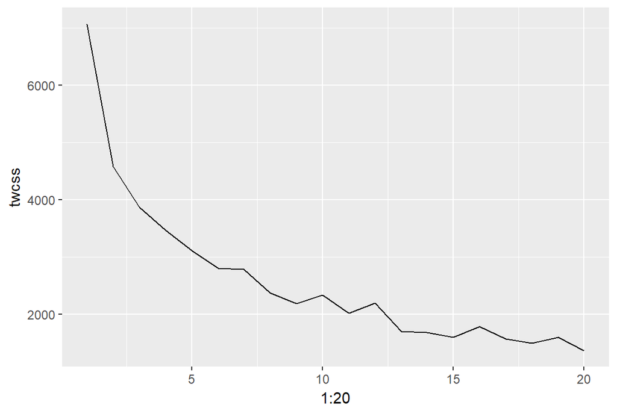

I notice that a relevant drop happens for a number of clusters equal to 2. I run the k-means algorithm with 2 clusters.

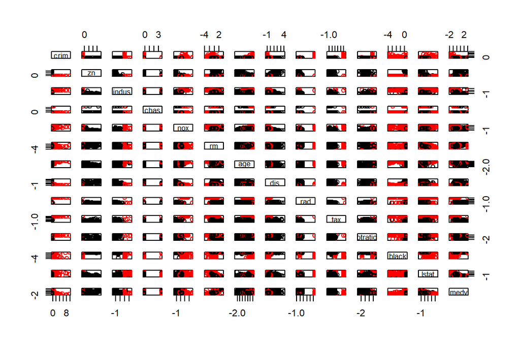

```r
km <-kmeans(boston_scaled, centers = 2)
pairs(boston_scaled, col = km$cluster)
```

Because of the high number of variables, to simplify the visualization I again restrict to the variables ‘tax’ and ‘rad’. With 2 clusters, we obtain the following.

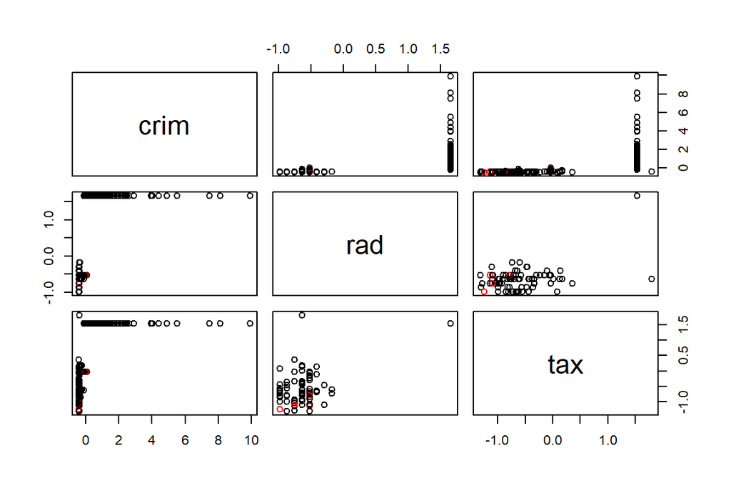

```r
km <-kmeans(boston_scaled, centers = 2)
pairs(boston_scaled[,selected], col = km$cluster)
```

## LDA on clusters

I perform k-means on the standardized dataset with an increased number of cluster equal to 7.

```r
# scale variables and set as data frame class
boston_scaled <- scale(boston_scaled)
boston_scaled <- as.data.frame(boston_scaled)

# k-means on 7 clusters
km <-kmeans(boston_scaled, centers = 7)
cluster <- km$cluster
boston_scaled <- data.frame(boston_scaled,cluster)

# divide train and test datasets
ind <- sample(n,  size = n * 0.8)
train <- boston_scaled[ind,]
test <- boston_scaled[-ind,]
```

Perform LDA using the clusters as target classes. Include all the variables in the Boston data in the LDA model. Visualize the results with a biplot (include arrows representing the relationships of the original variables to the LDA solution).

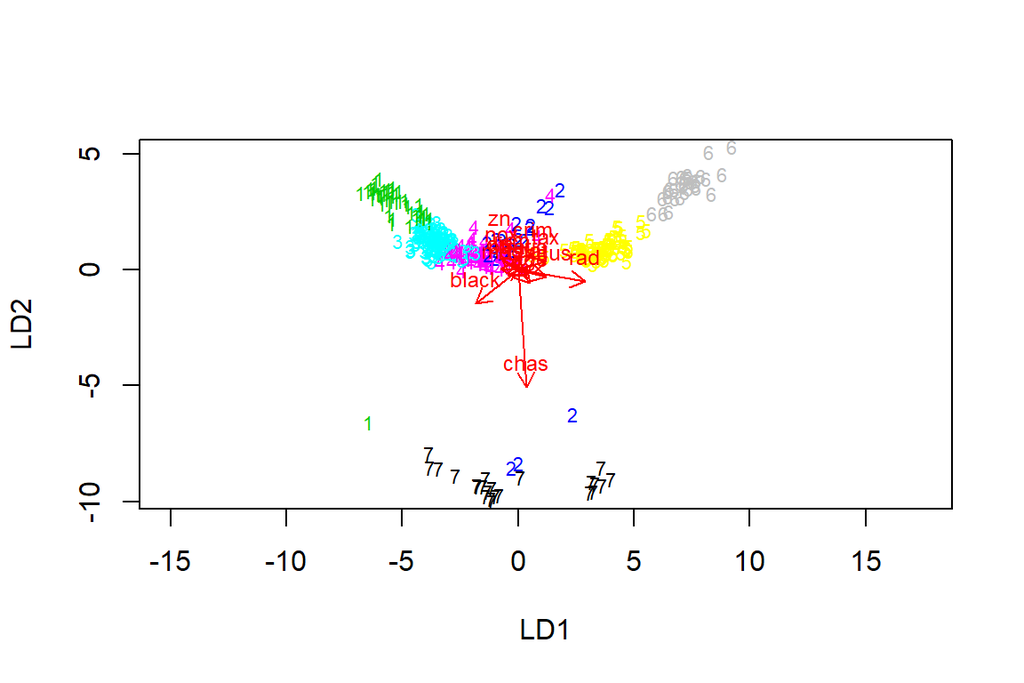

I now study how the model predict the classes, on the test subset formed by 102 observations: notice that good predictive power of the model.

```
##        predicted
## correct  1  2  3  4  5  6  7
##       1  9  0  0  0  0  0  0
##       2  0  2  0  0  0  0  1
##       3  0  1 36  0  0  0  0
##       4  0  0  5 14  0  0  0
##       5  0  0  0  0 18  0  0
##       6  0  0  0  0  0  9  0
##       7  0  0  0  0  0  0  7
```

# Chapter 5: Dimensionality reduction techniques

*Goal of this project is to study the human dataset and practice dimensionality reduction.*

What I learnt:

- (in the data wrangling exercise) to select only data observations that are complete (no NA values)
- to reduce large dimension (many variables) of the problem via PCA and interpret the biplot
- for categorical variables, to reduce the dimension via MCA and interpret the numerical and graphical outputs

## The dataset

The database we analyse this week is the ‘human’ database from the United Nations Development Programme. The database has the following structure:

```
## 'data.frame':    155 obs. of  8 variables:
##  $ Edu2.FM  : num  1.007 0.997 0.983 0.989 0.969 ...
##  $ Labo.FM  : num  0.891 0.819 0.825 0.884 0.829 ...
##  $ Edu.Exp  : num  17.5 20.2 15.8 18.7 17.9 16.5 18.6 16.5 15.9 19.2 ...
##  $ Life.Exp : num  81.6 82.4 83 80.2 81.6 80.9 80.9 79.1 82 81.8 ...
##  $ GNI      : int  64992 42261 56431 44025 45435 43919 39568 52947 42155 32689 ...
##  $ Mat.Mor  : int  4 6 6 5 6 7 9 28 11 8 ...
##  $ Ado.Birth: num  7.8 12.1 1.9 5.1 6.2 3.8 8.2 31 14.5 25.3 ...
##  $ Parli.F  : num  39.6 30.5 28.5 38 36.9 36.9 19.9 19.4 28.2 31.4 ...
```

The dataset has 8 variables and 155 observations, regarding the Human Development Index (HDI) and several variables summarising key aspects connected to it. Further information available [here](http://hdr.undp.org/en/content/human-development-index-hdi). For simplicity I renamed the variables according to the instructions in the exercise. Here are the descriptions of the variables names:

- “Edu2.FM” = Edu2.F / Edu2.M
- “Labo.FM” = Labo2.F / Labo2.M
- “Edu.Exp” = Expected years of schooling
- “Life.Exp” = Life expectancy at birth
- “GNI” = Gross National Income per capita
- “Mat.Mor” = Maternal mortality ratio
- “Parli.F” = Percentage of female representatives in parliament

## Overview of the variables

A summary of the variables and their correlation:

```
##     Edu2.FM          Labo.FM          Edu.Exp         Life.Exp
##  Min.   :0.1717   Min.   :0.1857   Min.   : 5.40   Min.   :49.00
##  1st Qu.:0.7264   1st Qu.:0.5984   1st Qu.:11.25   1st Qu.:66.30
##  Median :0.9375   Median :0.7535   Median :13.50   Median :74.20
##  Mean   :0.8529   Mean   :0.7074   Mean   :13.18   Mean   :71.65
##  3rd Qu.:0.9968   3rd Qu.:0.8535   3rd Qu.:15.20   3rd Qu.:77.25
##  Max.   :1.4967   Max.   :1.0380   Max.   :20.20   Max.   :83.50
##       GNI            Mat.Mor         Ado.Birth         Parli.F
##  Min.   :   581   Min.   :   1.0   Min.   :  0.60   Min.   : 0.00
##  1st Qu.:  4198   1st Qu.:  11.5   1st Qu.: 12.65   1st Qu.:12.40
##  Median : 12040   Median :  49.0   Median : 33.60   Median :19.30
##  Mean   : 17628   Mean   : 149.1   Mean   : 47.16   Mean   :20.91
##  3rd Qu.: 24512   3rd Qu.: 190.0   3rd Qu.: 71.95   3rd Qu.:27.95
##  Max.   :123124   Max.   :1100.0   Max.   :204.80   Max.   :57.50
```

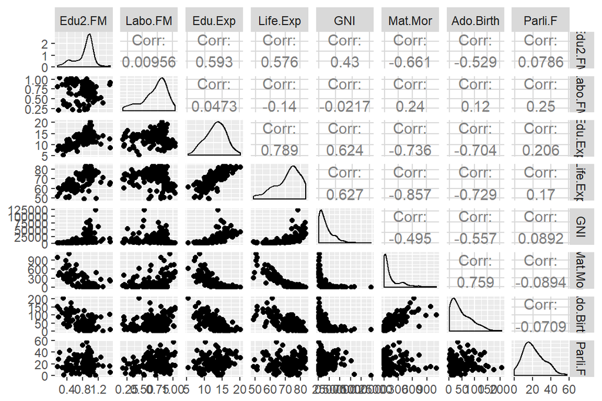

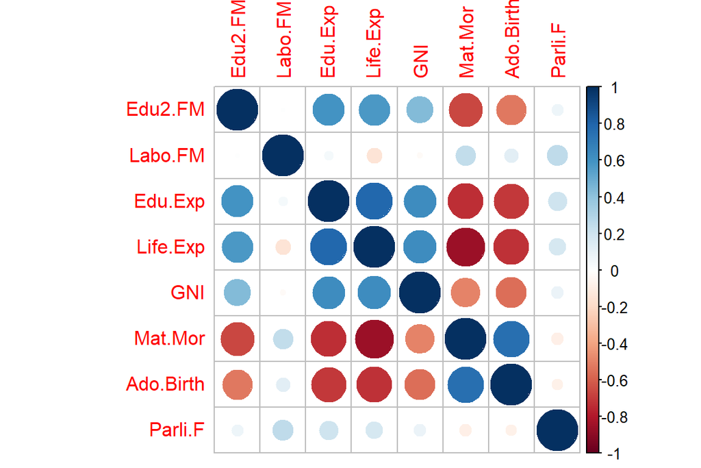

From the graphical correlation matrix it emerges that many variables are highly correlated with each other. This suggests that a reduction of dimensionality is interesting, because some of the variables, being highly correlated with some others, may not help in giving additional insight into the data. Hence we resort to PCA (Principal Component Analysis).

## PCA on the non-standardized dataset

I consider the *non standardized* dataset and perform the Principal Component Analysis (PCA). The summary of the PCA, together with a biplot, follows.

```
## Importance of components%s:
##                              PC1      PC2   PC3   PC4   PC5   PC6    PC7
## Standard deviation     1.854e+04 185.5219 25.19 11.45 3.766 1.566 0.1912
## Proportion of Variance 9.999e-01   0.0001  0.00  0.00 0.000 0.000 0.0000
## Cumulative Proportion  9.999e-01   1.0000  1.00  1.00 1.000 1.000 1.0000
##                           PC8
## Standard deviation     0.1591
## Proportion of Variance 0.0000
## Cumulative Proportion  1.0000
```

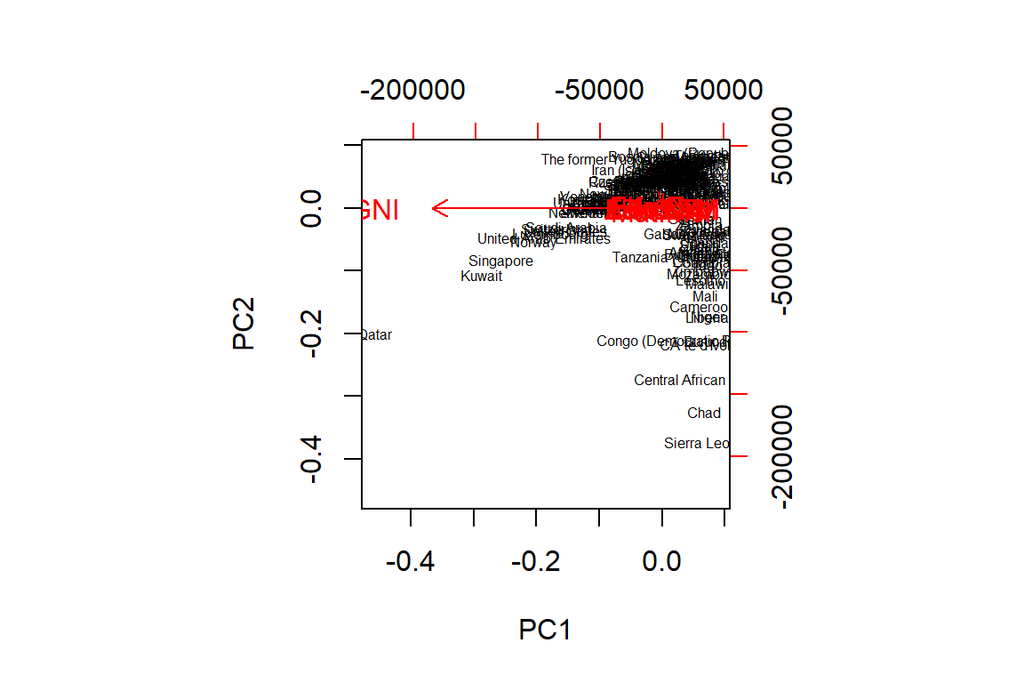

Figure 1: Biplot of PC on non-standardized ‘human’: the PCA is not useful to reduce the components because the variance of the GNI dominates by some orders of magnitude.

It is evident that almost all the variance is captured by the principal component, which is aligned with the variable GNI. This is because the variance of the variable GNI is itself on a completely different scale compared to the other variables. Indeed, notice the large difference between standard deviations of the principal components:

```
## [1] 1.854416e+04 1.855219e+02 2.518701e+01 1.145441e+01 3.766241e+00
## [6] 1.565912e+00 1.912052e-01 1.591112e-01
```

## PCA on the standardized dataset

I now consider the standardized dataset.

```
##     Edu2.FM           Labo.FM           Edu.Exp           Life.Exp
##  Min.   :-2.8189   Min.   :-2.6247   Min.   :-2.7378   Min.   :-2.7188
##  1st Qu.:-0.5233   1st Qu.:-0.5484   1st Qu.:-0.6782   1st Qu.:-0.6425
##  Median : 0.3503   Median : 0.2316   Median : 0.1140   Median : 0.3056
##  Mean   : 0.0000   Mean   : 0.0000   Mean   : 0.0000   Mean   : 0.0000
##  3rd Qu.: 0.5958   3rd Qu.: 0.7350   3rd Qu.: 0.7126   3rd Qu.: 0.6717
##  Max.   : 2.6646   Max.   : 1.6632   Max.   : 2.4730   Max.   : 1.4218
##       GNI             Mat.Mor          Ado.Birth          Parli.F
##  Min.   :-0.9193   Min.   :-0.6992   Min.   :-1.1325   Min.   :-1.8203
##  1st Qu.:-0.7243   1st Qu.:-0.6496   1st Qu.:-0.8394   1st Qu.:-0.7409
##  Median :-0.3013   Median :-0.4726   Median :-0.3298   Median :-0.1403
##  Mean   : 0.0000   Mean   : 0.0000   Mean   : 0.0000   Mean   : 0.0000
##  3rd Qu.: 0.3712   3rd Qu.: 0.1932   3rd Qu.: 0.6030   3rd Qu.: 0.6127
##  Max.   : 5.6890   Max.   : 4.4899   Max.   : 3.8344   Max.   : 3.1850
```

Next, I perform the PCA and present a biplot for the standardized dataset.

```
## Importance of components%s:
##                           PC1    PC2     PC3     PC4     PC5     PC6
## Standard deviation     2.0708 1.1397 0.87505 0.77886 0.66196 0.53631
## Proportion of Variance 0.5361 0.1624 0.09571 0.07583 0.05477 0.03595
## Cumulative Proportion  0.5361 0.6984 0.79413 0.86996 0.92473 0.96069
##                            PC7     PC8
## Standard deviation     0.45900 0.32224
## Proportion of Variance 0.02634 0.01298
## Cumulative Proportion  0.98702 1.00000
```

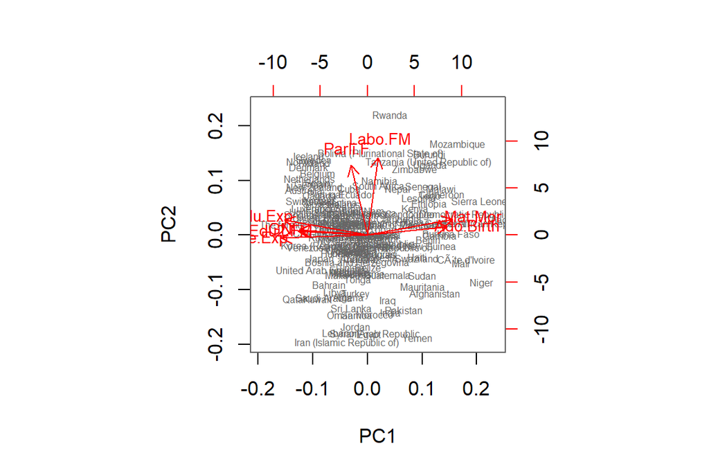

After standardization, the variance of different variables can be compared and their contribution to the total variance are of the same order of magnitude. The two first PC capture almost 70% of the cumulative variance.

## Interpretation of PCA

From the biplot, we observe that most of the variables are aligned with one of the two axis, so all the variables are higly correlated with either PC1 or PC2. The two variables ‘labo.FM’ and ‘Parli’ are strongly correlated with the PC2, while all the other variables are correlated with the PC1. Since the two PC captures almost 70% of the variance, they may be sufficient to get sgnificant insight on the data.

## Multiple Correspondence Analysis (MCA)

Consider the ‘tea’ dataset from the library ‘FactoMineR’.

```r
library(FactoMineR)
data("tea")
dim(tea)
```

```
## [1] 300  36
```

```r
str(tea)
```

```
## 'data.frame':    300 obs. of  36 variables:
##  $ breakfast       : Factor w/ 2 levels "breakfast","Not.breakfast": 1 1 2 2 1 2 1 2 1 1 ...
##  $ tea.time        : Factor w/ 2 levels "Not.tea time",..: 1 1 2 1 1 1 2 2 2 1 ...
##  $ evening         : Factor w/ 2 levels "evening","Not.evening": 2 2 1 2 1 2 2 1 2 1 ...
##  $ lunch           : Factor w/ 2 levels "lunch","Not.lunch": 2 2 2 2 2 2 2 2 2 2 ...
##  $ dinner          : Factor w/ 2 levels "dinner","Not.dinner": 2 2 1 1 2 1 2 2 2 2 ...
##  $ always          : Factor w/ 2 levels "always","Not.always": 2 2 2 2 1 2 2 2 2 2 ...
##  $ home            : Factor w/ 2 levels "home","Not.home": 1 1 1 1 1 1 1 1 1 1 ...
##  $ work            : Factor w/ 2 levels "Not.work","work": 1 1 2 1 1 1 1 1 1 1 ...
##  $ tearoom         : Factor w/ 2 levels "Not.tearoom",..: 1 1 1 1 1 1 1 1 1 2 ...
##  $ friends         : Factor w/ 2 levels "friends","Not.friends": 2 2 1 2 2 2 1 2 2 2 ...
##  $ resto           : Factor w/ 2 levels "Not.resto","resto": 1 1 2 1 1 1 1 1 1 1 ...
##  $ pub             : Factor w/ 2 levels "Not.pub","pub": 1 1 1 1 1 1 1 1 1 1 ...
##  $ Tea             : Factor w/ 3 levels "black","Earl Grey",..: 1 1 2 2 2 2 2 1 2 1 ...
##  $ How             : Factor w/ 4 levels "alone","lemon",..: 1 3 1 1 1 1 1 3 3 1 ...
```

[output cut: 22 more lines]

The dataset contains 300 observations of 36 variables regarding tea consumption.

For the following analysis, I choose only a limited subset of variables to simplify the analysis. I consider only the variables ‘frequency’, ‘How’, ‘Sport’, ‘effect.on.health’, ‘sex’, ‘home’, ‘exciting’, ‘relaxing’.

```
##        frequency      How                Sport
##  1/day      : 95   alone:195   Not.sportsman:121
##  1 to 2/week: 44   lemon: 33   sportsman    :179
##  +2/day     :127   milk : 63
##  3 to 6/week: 34   other:  9
##             effect.on.health sex           home            exciting
##  effect on health   : 66     F:178   home    :291   exciting   :116
##  No.effect on health:234     M:122   Not.home:  9   No.exciting:184
##
##
##         relaxing
##  No.relaxing:113
##  relaxing   :187
##
##
```

I perform the MCA analysis on the reduced dataset:

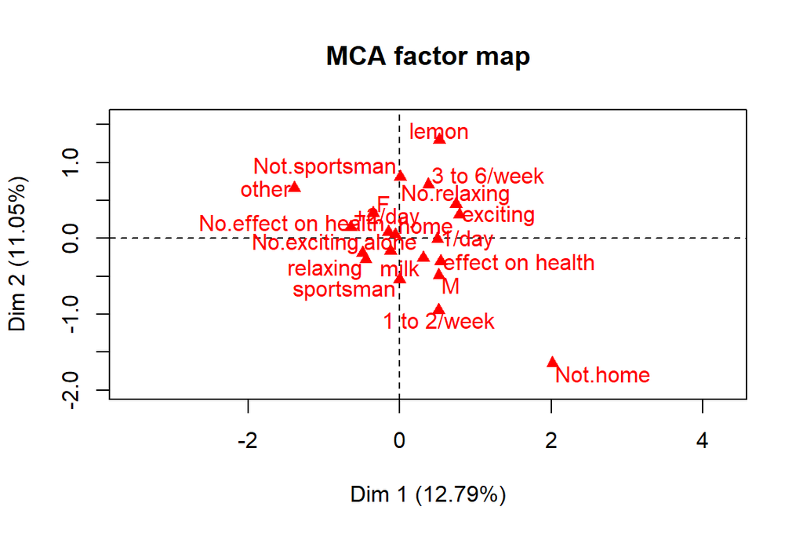

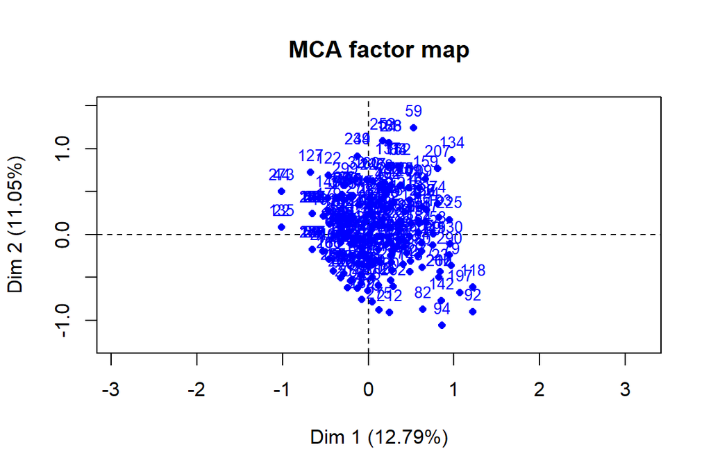

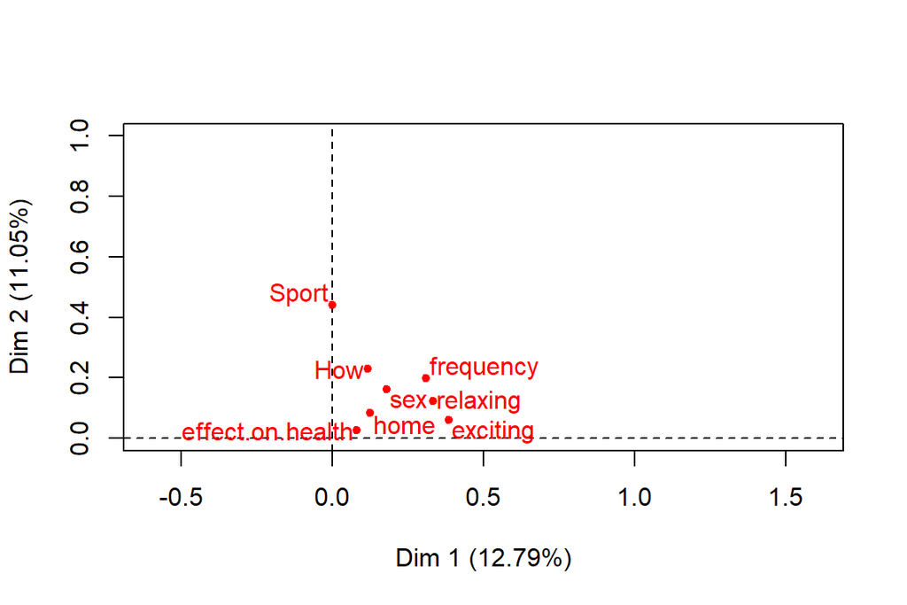

```
##
## Call:
## MCA(X = tea_red, graph = TRUE)
##
##
## Eigenvalues
##                        Dim.1   Dim.2   Dim.3   Dim.4   Dim.5   Dim.6
## Variance               0.192   0.166   0.149   0.138   0.134   0.127
## % of var.             12.786  11.047   9.945   9.172   8.940   8.480
## Cumulative % of var.  12.786  23.833  33.778  42.949  51.889  60.370
##                        Dim.7   Dim.8   Dim.9  Dim.10  Dim.11  Dim.12
## Variance               0.121   0.116   0.100   0.094   0.087   0.077
## % of var.              8.095   7.725   6.654   6.275   5.777   5.104
## Cumulative % of var.  68.465  76.190  82.844  89.119  94.896 100.000
##
## Individuals (the 10 first)
##                  Dim.1    ctr   cos2    Dim.2    ctr   cos2    Dim.3
## 1             |  0.261  0.119  0.074 | -0.251  0.127  0.068 | -0.035
## 2             |  0.502  0.438  0.186 |  0.129  0.034  0.012 | -0.444
## 3             | -0.652  0.738  0.706 | -0.174  0.061  0.050 |  0.180
## 4             | -0.076  0.010  0.006 | -0.059  0.007  0.004 | -0.075
## 5             | -0.405  0.284  0.234 | -0.426  0.365  0.260 |  0.066
## 6             | -0.078  0.011  0.008 | -0.474  0.452  0.282 | -0.042
## 7             | -0.112  0.022  0.008 | -0.253  0.128  0.042 |  0.262
## 8             | -0.198  0.068  0.025 | -0.537  0.579  0.184 | -0.200
## 9             | -0.281  0.137  0.072 | -0.453  0.413  0.187 | -0.524
## 10            | -0.402  0.281  0.202 | -0.010  0.000  0.000 |  0.033
##                  ctr   cos2
## 1              0.003  0.001 |
## 2              0.440  0.145 |
## 3              0.073  0.054 |
## 4              0.012  0.006 |
## 5              0.010  0.006 |
## 6              0.004  0.002 |
## 7              0.153  0.045 |
## 8              0.089  0.026 |
## 9              0.614  0.249 |
## 10             0.002  0.001 |
##
## Categories (the 10 first)
```

[output cut: 18 more lines]

```
## milk           -2.285 |  -1.415  35.224   0.532 -12.613 |
## other           2.023 |  -0.078   0.015   0.000  -0.238 |
## Not.sportsman  11.479 |  -0.061   0.125   0.003  -0.865 |
## sportsman     -11.479 |   0.041   0.085   0.003   0.865 |
##
## Categorical variables (eta2)
##                    Dim.1 Dim.2 Dim.3
## frequency        | 0.310 0.198 0.134 |
## How              | 0.118 0.230 0.539 |
## Sport            | 0.000 0.441 0.003 |
## effect.on.health | 0.081 0.026 0.156 |
## sex              | 0.181 0.163 0.030 |
## home             | 0.125 0.084 0.321 |
## exciting         | 0.386 0.061 0.010 |
## relaxing         | 0.332 0.124 0.000 |
```